# act_report

## Report: act_report on the twitter Account of WeRateDogs

Following the successful wrangling of the datasets on the WeRateDogs twitter Account, lets communicate the insights drawn from the final result of the data and visualize them for clearer picture. By the way, I'd hope the beautiful puppies staring at you appeals your fancy, they are cute, arent they?

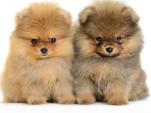

### Communicate Insights:

The following are my insights from the analysis carried out on the WeRateDogs datasets.

- Breed of Dog having the highest favorite_count.
- Breed of Dog having the highest rating_denominator.
- Breed of Dog having the lowest retweet_count.

In other to plot and actualize our visuals, the package matplotlip.pyploy as plt and %matplotlib inline was imported at the beginning of our wrangling process to handle plots and visuals in the analysis.

Following is the the reading of the saved dataset called twitter_archive_master (the final product of the analysis) in the python workspace using pandas: pd.read_csv.

### ploting and visualizing the insights

#### 1st Insight: Breed of Dog having the highest favorite_count.

A variable called dogs_favorite_count containing the grouping of the breed of dogs was created from the twitter_archive_master dataset using the groupby function and slicing the result to display the first 10 breeds for better visuals.

A bar chat is plotted with 'title = breed_of_dogs_with_favorite_count, ylabel = favorite_count, xlabel = breed_of_dogs and legend' parameters dully defined to properly visualize our insight using the imported plt library.

**the visual result:** shows that the dog breed: Miniature_Schnauzer has the highest favourite_count in the scale of 10 with over 4000+ favourite_count.

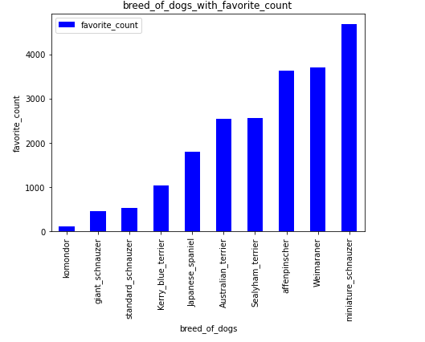

#### 2nd Insight: Breed of Dog having the highest rating_denominator.

A variable called dogs_rating_denominator containing the grouping of the breed of dogs was created from the twitter_archive_master dataset using the groupby function and slicing the result to display the first 10 breeds for better visuals.

**the visual result:** shows that the dog breeds: Sealyham_terrier, Australian_terrier and Scotch_terrier have the highest rating_denominator in the scale of 10 breeds.

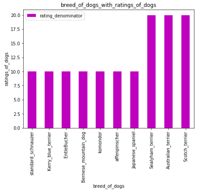

#### 3rd Insight: Breed of Dog having the lowest retweet_count.

A variable called dogs_retweet_count containing the grouping of the breed of dogs was created from the twitter_archive_master dataset using the groupby function and slicing the result to display the first 10 breeds for better visuals.

A bar chat is plotted with 'title = breed_of_dogs_with_retweet_count, ylabel = retweet_count, xlabel = breed_of_dogs and legend' parameters dully defined to properly visualize our insight using the imported plt library.

**the visual result:** shows that the dog breed: Komondor has the lowest retweet_count in the scale of 10 breeds with a count less than 250

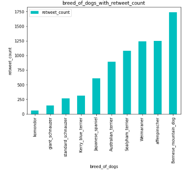